# Exploratory Data Analysis

Pro-environmental Project

# Project Summary

```r
library(rio) # for importing data
library(tidyverse) # for tidyverse tools
library(psych) # for descriptive statistics
library(Hmisc) # for histogram matrix
library(readr) # for exporting csv files
library(corrplot) # for a correlation matrix plot
library(naniar) # for visualizing missingness & MCAR test
library(cowplot) # for plotting multiple visualizations
library(GGally) # for scatterplot matrices
```

# Importing Data

## Import Data

```r
data <- import("proenv_clean_data.csv")
```

## Check Measure Types

```r
str(data, list.len = ncol(data))
```

## Transform Measure Types

```r
data <- data %>%
  mutate(id = as.factor(id),
         consumer_behaviors = as.factor(consumer_behaviors),
         framing_condition = as.factor(framing_condition),
         norm_condition = as.factor(norm_condition),
         Gender = as.factor(Gender),
         Class_Lvl = as.factor(Class_Lvl),
         Employment = as.factor(Employment),
         Parents_Education = as.factor(Parents_Education),
         Pol_Ornt = factor(Pol_Ornt, labels = c("Very liberal", "Somewhat liberal", "Slightly liberal", "Neither liberal nor conservative", "Slightly conservative", "Somewhat conservative", "Very conservative", "Other")),
         Ethnicity = as.factor(Ethnicity))
```

## Subset Key Variables

```r
data <- data %>%
  dplyr::select(id, framing_condition, norm_condition, biospheric, egoistic, clothing_interest, ingroup_identification, consumer_intentions, consumer_behaviors, Age, Gender)
```

# Descriptive Tables

## Consumer Intentions

Consumer Intentions across Framing Conditions

| Framing Condition | n | Mean | SD |
| --- | --- | --- | --- |
| Control | 377 | 4.34 | 1.23 |
| Pro-Environmental | 379 | 4.49 | 1.13 |
| Self-Enhancing | 375 | 4.41 | 1.21 |

Consumer Intentions across Norm Conditions

| Norm Condition | n | Mean | SD |
| --- | --- | --- | --- |
| Control | 229 | 4.45 | 1.23 |
| Convention | 228 | 4.55 | 1.24 |
| Descriptive Norm | 226 | 4.42 | 1.12 |
| Moral Norm | 225 | 4.35 | 1.17 |
| Social Norm | 223 | 4.30 | 1.18 |

## Consumer Behaviors

Proportion of Pro-Environmental Consumer Behaviors across Framing Conditions

| Framing Condition | Consumer Behaviors | n | Proportion |
| --- | --- | --- | --- |
| Control | New Clothing | 216 | 0.58 |
| Control | Secondhand Clothing | 155 | 0.42 |
| Pro-Environmental | New Clothing | 181 | 0.48 |
| Pro-Environmental | Secondhand Clothing | 193 | 0.52 |
| Self-Enhancing | New Clothing | 197 | 0.54 |
| Self-Enhancing | Secondhand Clothing | 171 | 0.46 |

Proportion of Pro-Environmental Consumer Behaviors across Norm Conditions

| Framing Condition | Consumer Behaviors | n | Proportion |
| --- | --- | --- | --- |
| Control | New Clothing | 124 | 0.55 |
| Control | Secondhand Clothing | 100 | 0.45 |
| Convention | New Clothing | 116 | 0.51 |
| Convention | Secondhand Clothing | 110 | 0.49 |
| Descriptive Norm | New Clothing | 120 | 0.53 |
| Descriptive Norm | Secondhand Clothing | 105 | 0.47 |
| Moral Norm | New Clothing | 116 | 0.53 |
| Moral Norm | Secondhand Clothing | 103 | 0.47 |
| Social Norm | New Clothing | 118 | 0.54 |
| Social Norm | Secondhand Clothing | 101 | 0.46 |

## Values

Biospheric and Egoistic Values across Framing Conditions

| Framing Condition | n | Mean Biospheric | SD | Mean Egoistic | SD |
| --- | --- | --- | --- | --- | --- |
| Control | 377 | 5.86 | 1.02 | 4.96 | 0.92 |
| Pro-Environmental | 379 | 5.84 | 1.00 | 5.04 | 0.91 |
| Self-Enhancing | 375 | 5.89 | 0.95 | 4.98 | 0.93 |

| Norm Condition | n | Mean Biospheric | SD | Mean Egoistic | SD |
| --- | --- | --- | --- | --- | --- |
| Control | 229 | 5.84 | 0.96 | 4.99 | 0.89 |
| Convention | 228 | 5.82 | 1.00 | 4.93 | 0.96 |
| Descriptive Norm | 226 | 5.87 | 0.97 | 5.04 | 0.83 |
| Moral Norm | 225 | 5.89 | 1.05 | 5.00 | 0.95 |
| Social Norm | 223 | 5.89 | 0.97 | 5.00 | 0.95 |

## Ingroup Identification

Ingroup Identification across Framing Conditions

| Framing Condition | n | Mean | SD |
| --- | --- | --- | --- |
| Control | 377 | 4.64 | 1.06 |
| Pro-Environmental | 379 | 4.64 | 0.99 |
| Self-Enhancing | 375 | 4.64 | 0.99 |

Ingroup Identification across Norm Conditions

| Norm Condition | n | Mean | SD |
| --- | --- | --- | --- |
| Control | 229 | 4.59 | 1.04 |
| Convention | 228 | 4.57 | 0.99 |
| Descriptive Norm | 226 | 4.74 | 0.99 |
| Moral Norm | 225 | 4.66 | 1.02 |
| Social Norm | 223 | 4.63 | 1.03 |

## Clothing Interest

Clothing Interest across Framing Conditions

| Framing Condition | n | Mean | SD |
| --- | --- | --- | --- |
| Control | 377 | 3.15 | 0.82 |
| Pro-Environmental | 379 | 3.12 | 0.80 |
| Self-Enhancing | 375 | 3.13 | 0.79 |

Clothing Interest across Norm Conditions

| Norm Condition | n | Mean | SD |
| --- | --- | --- | --- |
| Control | 229 | 3.15 | 0.83 |
| Convention | 228 | 2.99 | 0.78 |
| Descriptive Norm | 226 | 3.17 | 0.77 |
| Moral Norm | 225 | 3.24 | 0.75 |
| Social Norm | 223 | 3.12 | 0.86 |

## Age

Age across Framing Conditions

| Framing Condition | n | Mean | SD |
| --- | --- | --- | --- |
| Control | 377 | 19.81 | 1.63 |
| Pro-Environmental | 379 | 20.00 | 1.92 |
| Self-Enhancing | 375 | 19.81 | 2.26 |

Age across Norm Conditions

| Norm Condition | n | Mean | SD |
| --- | --- | --- | --- |
| Control | 229 | 19.81 | 2.67 |
| Convention | 228 | 19.85 | 1.46 |
| Descriptive Norm | 226 | 19.94 | 1.75 |
| Moral Norm | 225 | 19.98 | 1.77 |
| Social Norm | 223 | 19.81 | 1.89 |

## Gender

Proportion of Genders across Framing Conditions

| Framing Condition | Gender | n | Proportion |
| --- | --- | --- | --- |
| Control | Men | 142 | 0.38 |
| Control | Non-binary | 5 | 0.01 |
| Control | Other | 1 | 0.00 |
| Control | Prefers to not identify | 2 | 0.01 |
| Control | Women | 227 | 0.60 |
| Pro-Environmental | Men | 134 | 0.35 |
| Pro-Environmental | Non-binary | 12 | 0.03 |
| Pro-Environmental | Other | 3 | 0.01 |
| Pro-Environmental | Prefers to not identify | 4 | 0.01 |
| Pro-Environmental | Women | 226 | 0.60 |
| Self-Enhancing | Men | 141 | 0.38 |
| Self-Enhancing | Non-binary | 7 | 0.02 |
| Self-Enhancing | Other | 2 | 0.01 |
| Self-Enhancing | Prefers to not identify | 5 | 0.01 |
| Self-Enhancing | Women | 220 | 0.59 |

Proportion of Genders across Norm Conditions

| Norm Condition | Gender | n | Proportion |
| --- | --- | --- | --- |
| Control | Men | 81 | 0.35 |
| Control | Non-binary | 4 | 0.02 |
| Control | Other | 1 | 0.00 |
| Control | Women | 143 | 0.62 |
| Convention | Men | 92 | 0.40 |
| Convention | Non-binary | 3 | 0.01 |
| Convention | Other | 3 | 0.01 |
| Convention | Prefers to not identify | 4 | 0.02 |
| Convention | Women | 126 | 0.55 |
| Descriptive Norm | Men | 85 | 0.38 |
| Descriptive Norm | Non-binary | 5 | 0.02 |
| Descriptive Norm | Prefers to not identify | 1 | 0.00 |
| Descriptive Norm | Women | 135 | 0.60 |
| Moral Norm | Men | 78 | 0.35 |
| Moral Norm | Non-binary | 5 | 0.02 |
| Moral Norm | Other | 1 | 0.00 |
| Moral Norm | Prefers to not identify | 4 | 0.02 |
| Moral Norm | Women | 137 | 0.61 |
| Social Norm | Men | 81 | 0.36 |
| Social Norm | Non-binary | 7 | 0.03 |
| Social Norm | Other | 1 | 0.00 |
| Social Norm | Prefers to not identify | 2 | 0.01 |
| Social Norm | Women | 132 | 0.59 |

## Notes

**Pro-Environmental Consumer Intentions:**

- Intentions to engage in pro-environmental consumer behaviors were similar across all framing conditions, but were descriptively highest when the decision was prefaced by a pro-environmental framing and lowest when the decision was prefaced by no framing (control condition).
- Intentions to engage in pro-environmental consumer behaviors were also similar across all norm conditions, but were descriptively highest when the decision was prefaced by a description of a convention for consuming pro-environmentally and lowest when the decision was prefaced by a description of a social norm for consuming pro-environmentally.

**Pro-Environmental Consumer Behaviors:**

- When a pro-environmental consumer behavior was prefaced by the control condition (no framing) and by the self-enhancing framing, people opted for a gift card to spend on new clothing more than they opted for a gift card to spend on secondhand clothing. When a pro-environmental framing was used, however, the proportion of choosing a gift card to spend on secondhand clothing was higher than the proportion of people choosing a gift card to spend on new clothing.
- The distribution of people choosing the a gift card to spend on new versus on secondhand clothing was similar across all norm intervention conditions. There were slightly more than 50% of participants choosing the gift card to spend on new clothing across all norm conditions.

**Covariates:**

- The distribution of participants’ levels on all covariates (values, ingroup identification, clothing interest, age, gender) was similar across all levels of the framing and norm intervention conditions.

# Univariate Data Visualizations

- Setting customized preferences for text on visualizations

```r
text_settings <-
  theme(plot.title = element_text(size = 12, face = 'bold')) +
  theme(plot.subtitle = element_text(size = 8)) +
  theme(axis.title.x = element_text(size = 10, face = 'bold')) +
  theme(axis.title.y = element_text(size = 10, face = 'bold')) +
  theme(axis.text.x = element_text(size = 9)) +
  theme(axis.text.y = element_text(size = 10)) +
  theme(plot.title = element_text(hjust = 0.5),
        plot.subtitle = element_text(hjust = 0.5))
```

## Consumer Intentions

### Across Norm Conditions

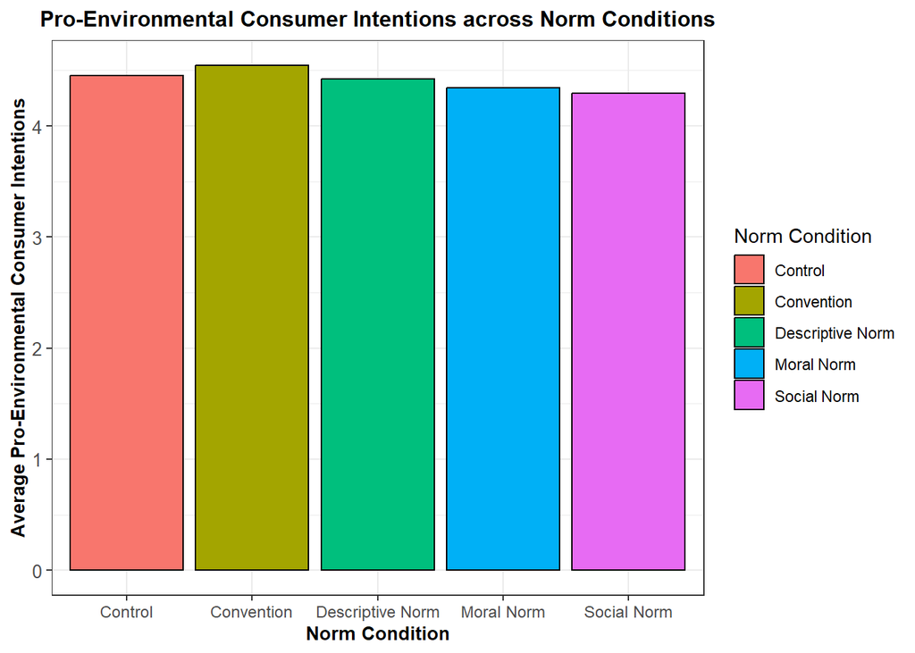

- Pro-environmental consumer intentions were similar across all norm conditions but slightly higher in the convention condition than the other norm conditions.

### Across Framing Conditions

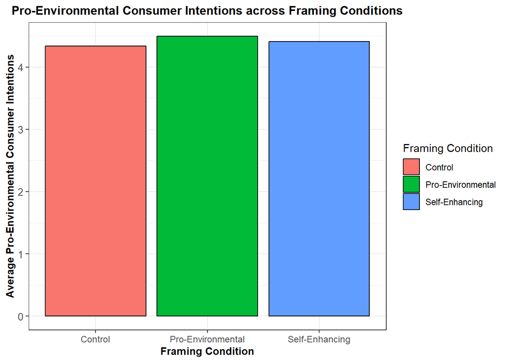

- Pro-environmental consumer intentions were slightly higher in the pro-environmental framing condition compared to the other framing conditions.

## Consumer Behaviors

### Across Norm Conditions

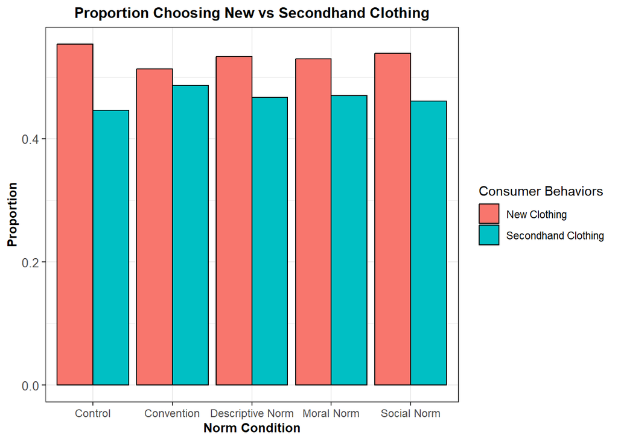

- The proportion of people opting for a gift card to spend on new clothing (environmentally harmful decision) instead of on secondhand clothing (pro-environmental decision) was higher across all norm conditions.
  - However, the difference was smallest in the convention condition and largest when no normative message was used (control).

### Across Framing Conditions

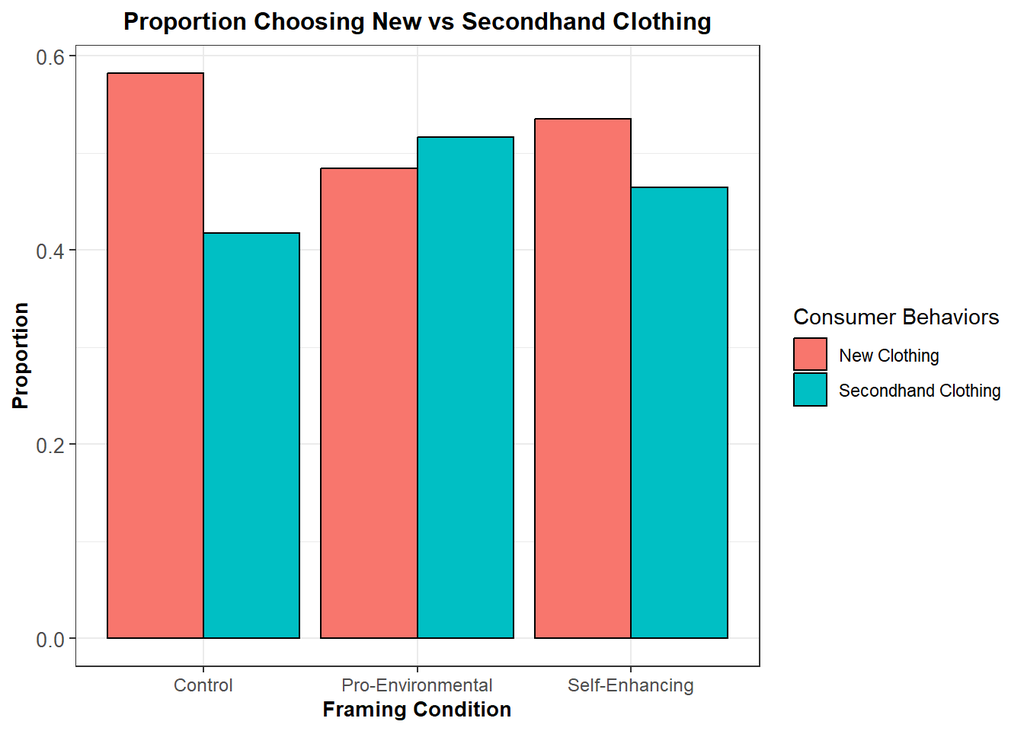

- The proportion of people opting for a gift card to spend on secondhand clothing (pro-environmental decision) rather than on new clothing (environmentally harmful decision) was higher only when the choice was prefaced by a pro-environmental framing.
  - The proportion of people opting for a gift card to spend new clothing rather than secondhand clothing was highest when no framing was used (control).

## Values

### Biospheric Values

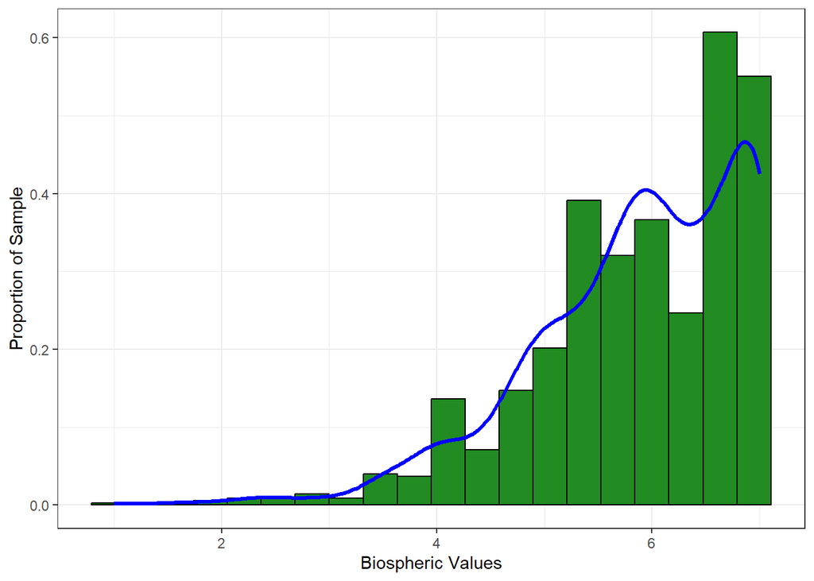

- The participants highly endorsed biospheric values.
  - Scores on biospheric values were negatively skewed, suggesting our sample represents people high on this measure but not many people mid- to low on biospheric values.

### Egoistic Values

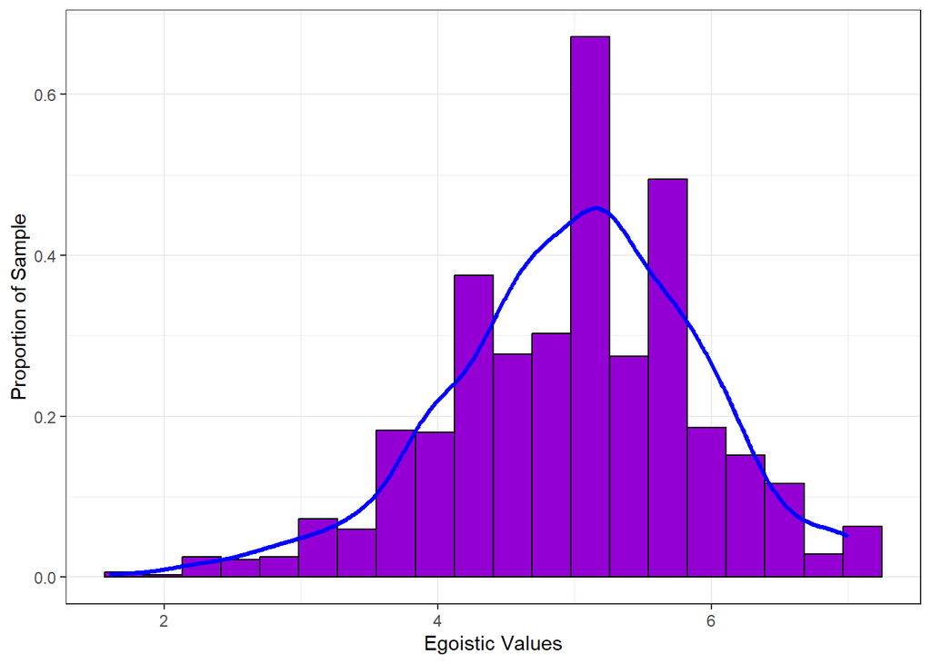

- Participants’ scores on egoistic values were approximately normally distributed.
  - The mean was above the midpoint of the scale (*M* = 4.99, *SD* = 0.92), suggesting the sample on average leaned towards endorsing egoistic values.

## Ingroup Identification

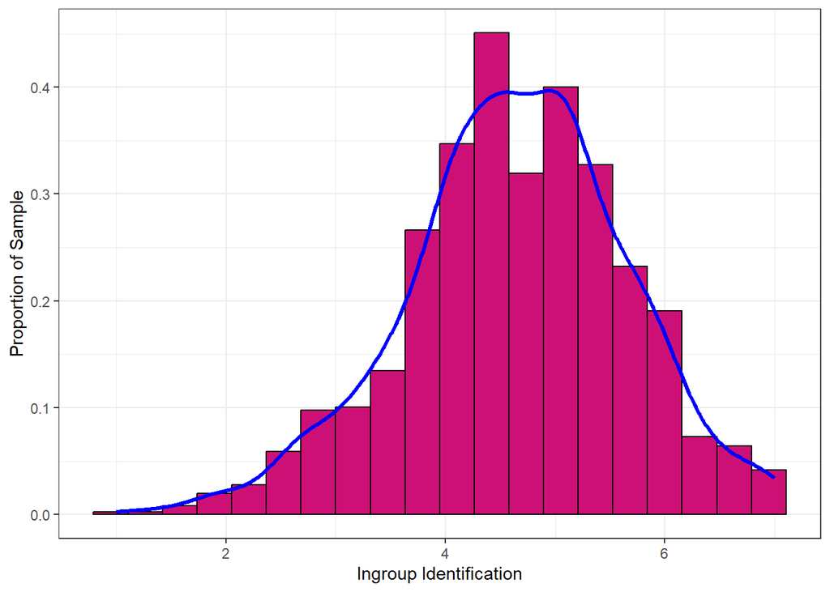

- Participants’ scores on ingroup identification were approximately normally distributed.
  - The mean was slightly above the midpoint of the scale (*M* = 4.64, *SD* = 1.01), suggesting participants tended identify with the reference group (other University of Oregon students).

## Interest in Clothing

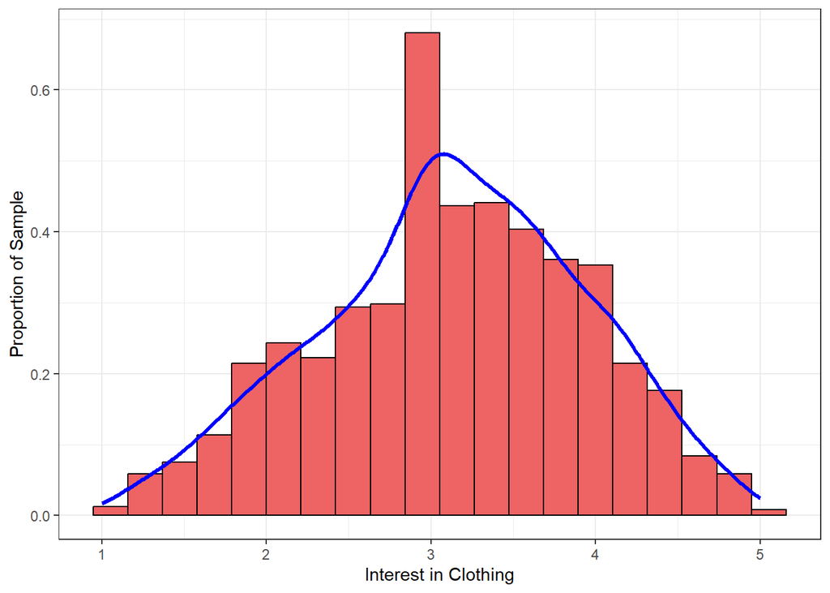

- Participants’ scores on interest in clothing were approximately normally distributed.
  - The mean was near the midpoint of the scale (*M* = 3.13, *SD* = 0.80), suggesting about half of the sample expressed interest in clothing and about half did not express interest in clothing.

# Bivariate Data Visualizations

## Biospheric Values and Consumer Intentions

### Overall

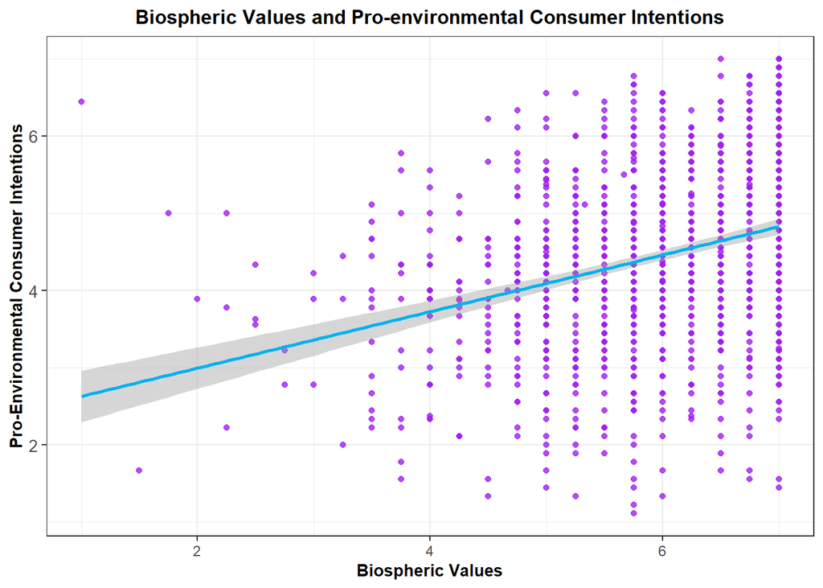

### Across Norm Conditions

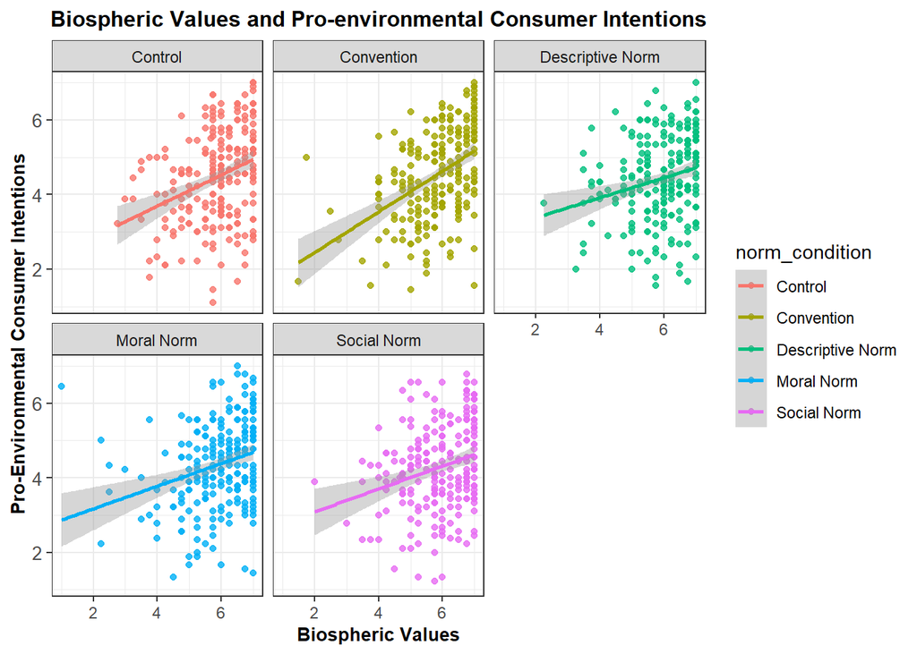

### Across Framing Conditions

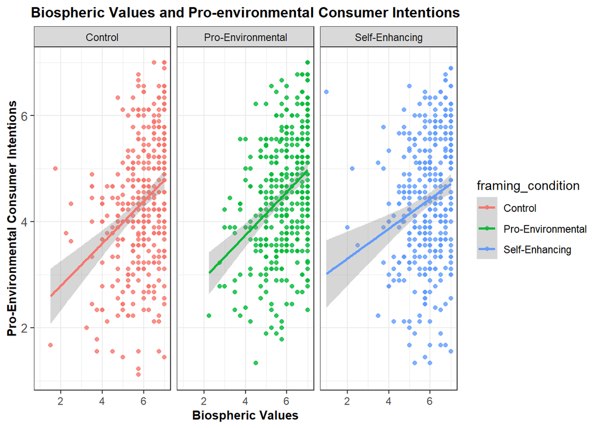

### Notes

- There was a general positive association between endorsement of biospheric values and intentions to engage in pro-environmental consumer behaviors.
  - This relationship was consistent across the framing and norm intervention conditions.

## Egoistic Values and Consumer Intentions

### Overall

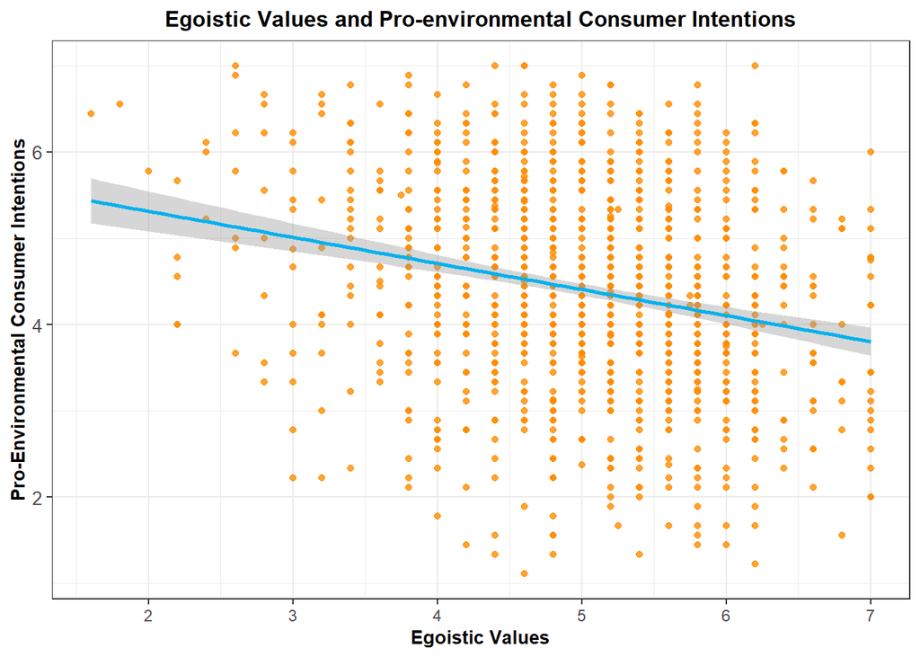

### Across Norm Conditions

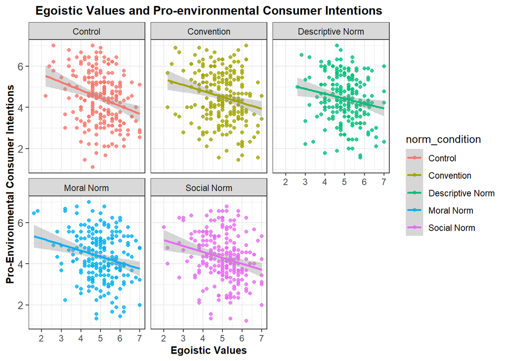

### Across Framing Conditions

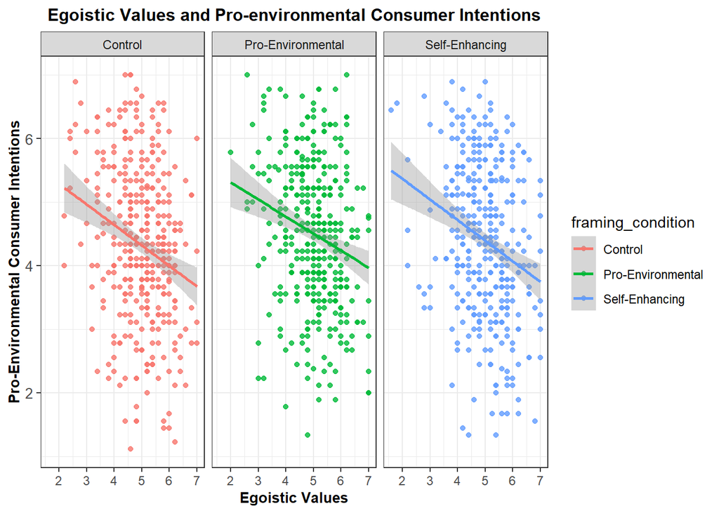

### Notes

- There was a general negative association between endorsement of egoistic values and intentions to engage in pro-environmental consumer behaviors.
  - This relationship was consistent across the framing and norm intervention conditions.

## Interest in Clothing and Consumer Intentions

### Overall

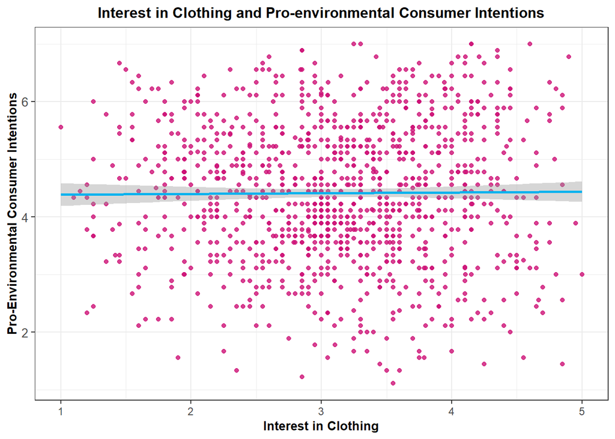

### Across Norm Conditions

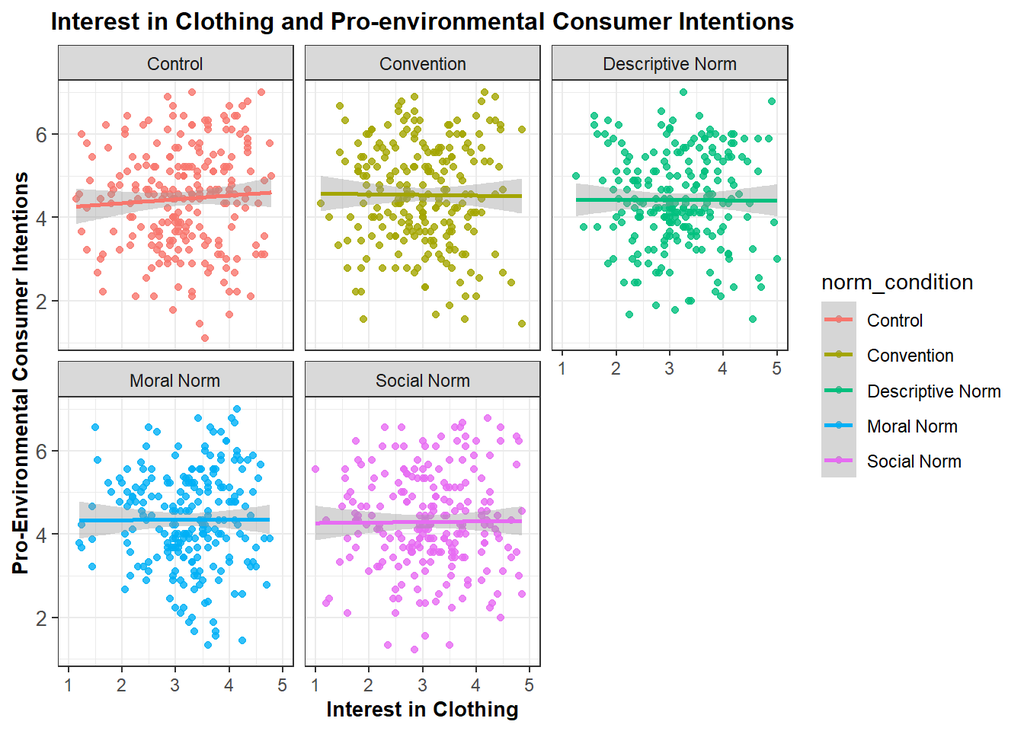

### Across Framing Conditions

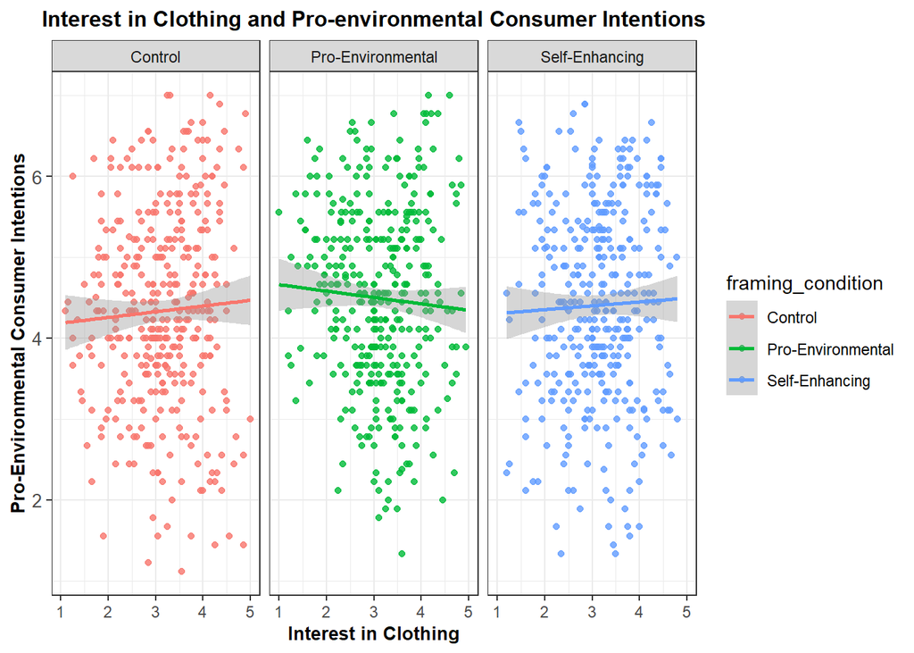

### Notes

- There was little to no association between participants’ interest in clothing and their intentions to engage in pro-environmental consumer behaviors.
  - This lack of a relationship was generally consistent across the framing and norm intervention conditions.

## Ingroup Identification and Consumer Intentions

### Overall

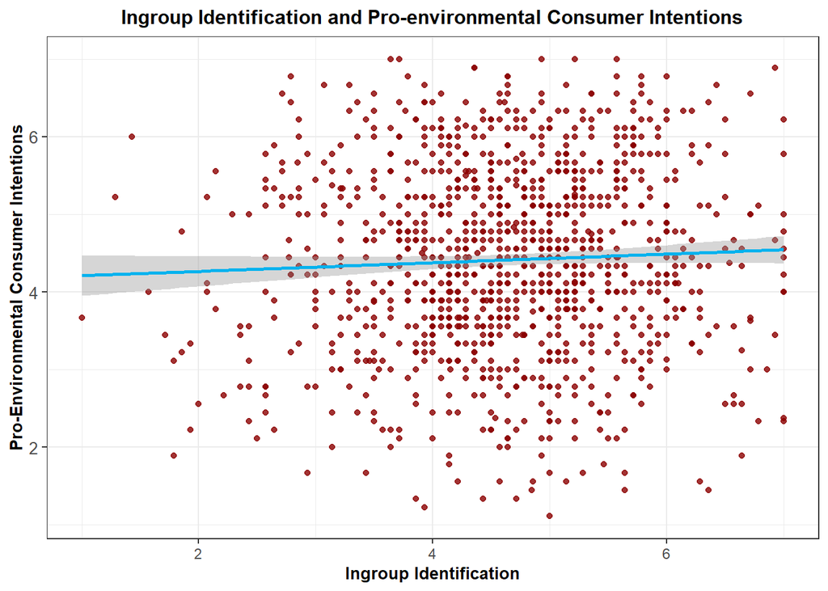

### Across Norm Conditions

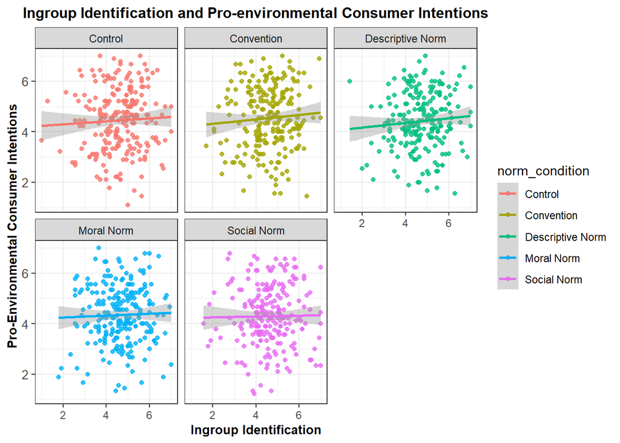

### Across Framing Conditions

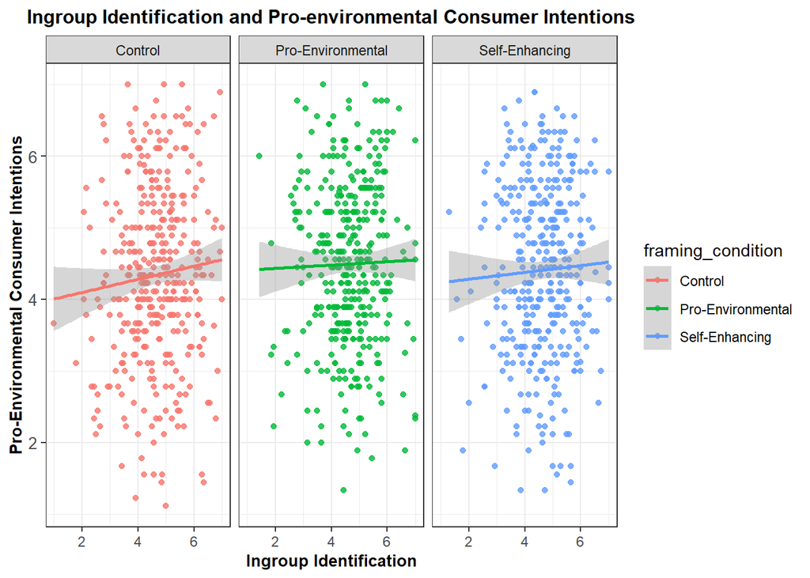

### Notes

- There was a slightly positive, but not substantial, association between the degree to which participants identified with the reference group (other UO students) and their intentions to engage in pro-environmental consumer behaviors.